# Example(bank data)

Jong-June Jeon

May, 2018

## Bank data set

## Bank data 설명

- 포르투갈 금융기관의 직접 마케팅한 캠페인 데이터
- 은행에서의 상품에 대해 구매시 "yes", 구매를 안하면 "no"
- 데이터 출처 : https://archive.ics.uci.edu/ml/datasets/Bank+Marketing
- 21개 변수(20개의 설명변수와 1개의 종속변수)와 41188개 관측치
- 변수 설명
  - 결과(y) : 상품 구매 여부 (2개 범주)

## Bank data 설명

- 변수 설명 (고객 데이터)
  - age : 연령
  - job : 직업 (12개 범주: "admin", "blue-collar", "entrepreneur", "housemaid", "management", "retired", "self-employed", "services", "student", "technician", "unemployed", "unknown")
  - marital : 혼인여부 (4개 범주 : "divorced", "married", "single", "unknown")
  - education : 교육수준 (8개 범주 : "basic.4y", "basic.6y", "basic.9y", "high.school", "illiterate", "professional.course", "university.degree", "unknown")
  - default : credit 유무 (3개 범주 : "no", "yes", "unknown")
  - housing : 주택융자 유무 (3개 범주 : "no", "yes", "unknown")
  - loan : 개인융자 유무 (3개 범주 : "no", "yes", "unknown")

## Bank data 설명

- 변수 설명 (현재 캠페인과 마지막 컨택간의 관계)
  - contact : 컨택 방법 (2개 범주 : "cellular", "telephone")
  - month : 마지막 컨택한 월 (10개 범주 : "mar", "apr", …, "nov", "dec")
  - day_of_week : 마지막 컨택한 요일 (5개 범주 : "mon", "tue", "wed", "thu", "fri")
  - duration : 마지막 컨택시간 (초 단위)
  - campaign : 고객과 컨택한 횟수
  - pdays : 이전 캠페인에서 마지막으로 컨텍이후 지난 일수 (999 : 이전 컨텍이 없었음)
  - previous : 이번 캠페인 시작하기전 컨택한 횟수
  - poutcome : 이전 마케팅 캠페인에 대한 결과 (3개 범주 : "failure", "nonexistent", "success")

## Bank data 설명

- 변수 설명 (사회 및 경제 지표)
  - emp.var.rate : 고용 변동률 (분기별 지표)
  - cons.price.idx : 소비자 물가 지수 (월별 지표)
  - cons.conf.idx : 소비자 신뢰 지수 (월별 지표)
  - euribor3m : 보증금 (일별 지표)
  - nr.employed : 종업원 수 (분기별 지표)

## 데이터 구조

```r
str(bank_dat)
```

```
## 'data.frame':    41188 obs. of  21 variables:
##  $ age           : int  56 57 37 40 56 45 59 41 24 25 ...
##  $ job           : chr  "housemaid" "services" "services" "admin." ...
##  $ marital       : chr  "married" "married" "married" "married" ...
##  $ education     : chr  "basic.4y" "high.school" "high.school" "basic.6y" ...
##  $ default       : chr  "no" "unknown" "no" "no" ...
##  $ housing       : chr  "no" "no" "yes" "no" ...
##  $ loan          : chr  "no" "no" "no" "no" ...
##  $ contact       : chr  "telephone" "telephone" "telephone" "telephone" ...
##  $ month         : Factor w/ 10 levels "Mar","Apr","May",..: 3 3 3 3 3 3 3 3 3 3 ...
##  $ day_of_week   : chr  "mon" "mon" "mon" "mon" ...
##  $ duration      : int  261 149 226 151 307 198 139 217 380 50 ...
##  $ campaign      : int  1 1 1 1 1 1 1 1 1 1 ...
##  $ pdays         : int  999 999 999 999 999 999 999 999 999 999 ...
##  $ previous      : int  0 0 0 0 0 0 0 0 0 0 ...
##  $ poutcome      : chr  "nonexistent" "nonexistent" "nonexistent" "nonexistent" ...
##  $ emp.var.rate  : num  1.1 1.1 1.1 1.1 1.1 1.1 1.1 1.1 1.1 1.1 ...
##  $ cons.price.idx: num  94 94 94 94 94 ...
##  $ cons.conf.idx : num  -36.4 -36.4 -36.4 -36.4 -36.4 -36.4 -36.4 -36.4 -36.4 -36.4 ...
##  $ euribor3m     : num  4.86 4.86 4.86 4.86 4.86 ...
##  $ nr.employed   : num  5191 5191 5191 5191 5191 ...
##  $ y             : chr  "no" "no" "no" "no" ...
```

## 직업별 구매여부

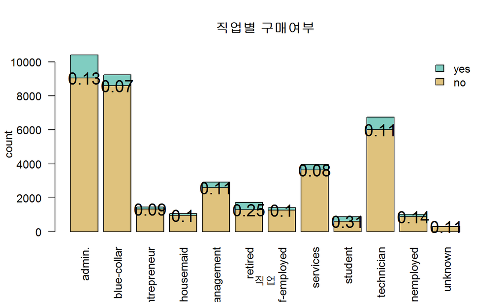

- 전체 빈도수 중 "yes"와 "no"의 횟수와 비율을 표현한 그래프이다.
- 하지만 같은 비율을 가지더라도 "yes"가 차지하는 공간은 다르다. 그러므로 전체를 통일시켜 얼만큼의 비율을 차지하는지 보는 그래프를 그려야 한다.

## Code

```r
counts = xtabs( ~ y + job, data = bank_dat)
prob = prop.table(xtabs( ~ y + job, data = bank_dat), 2)

b_plot = barplot(counts, main="직업별 구매여부", ylab = "count",
        xlab = "직업", col = c(brewer.pal(5, 'BrBG')[c(2, 4)]),
        legend = rownames(counts),
        args.legend = list(x ='topright', bty='n'), las=2)
text(b_plot, counts[1, ], labels = round(prob[2, ], 2), cex = 1.5)
```

- prop.table : xtabs으로 table을 구하고, table안의 비율을 계산해주는 함수
  - option으로 2를 지정 : column별 비율 계산
- barplot option
  - main : 그래프 제목, xlab : x축 이름, ylab : y축 이름, col : 색상 지정
  - legend : 범례 이름, args.legend : 위치(x) 및 틀 (bty) 제거
  - las : x축 이름을 세로로 지정

## 직업별 구매여부

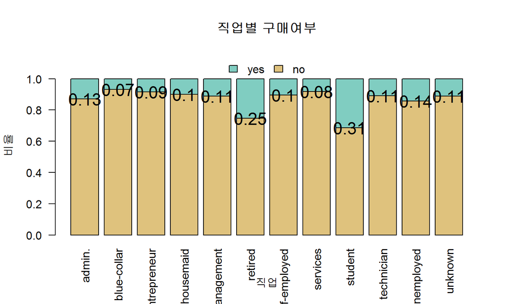

- 구매 여부 중 "yes"의 비율에 대해 그래프로 표현하였고, 앞서 본 그래프보다 구매 비율에 대한 전달이 잘 된다.

## Code

```r
prob = prop.table(xtabs( ~ y + job, data = bank_dat), 2)

b_plot = barplot(prob, main="직업별 구매여부", ylab = "비율",
        xlab = "직업", col = c(brewer.pal(5, 'BrBG')[c(2, 4)]),
        legend = rownames(counts),  ylim = c(0, 1.15),
        args.legend = list(x = "top", bty="n", ncol = 2), las=2)
text(b_plot, prob[1, ], labels = round(prob[2, ], 2), cex = 1.5)
```

- barplot option2
  - ncol : legend의 이름의 colmun 갯수 지정
  - las : x축 이름들을 세로로 써줌
  - ylim : y축의 축 스케일 지정
- text(x, y, labels = ~, cex = ~) : plot에 글을 써주함 함수
- round function : 반올림할 소수점 자리 지정

## 컨택 방법별 구매여부

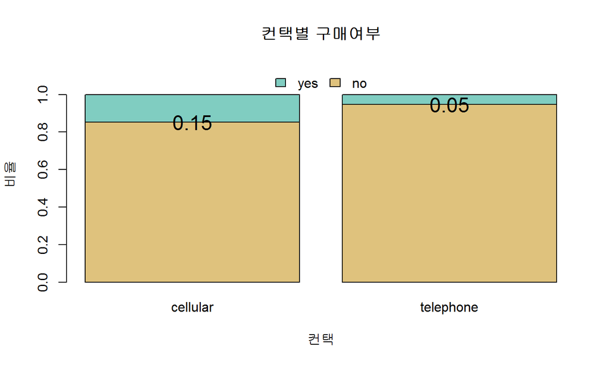

- cellular가 telephone으로 컨택했을때 보다 3배가 높다.
  - 마케팅시 같은 비용으로 컨택을 했다면, cellular가 telephone보다 이익을 3배를 더 얻을수 있다는 것이다.

## Code

```r
prob = prop.table(xtabs( ~ y + contact, data = bank_dat), 2)

b_plot = barplot(prob, main="컨택별 구매여부", ylab = "비율",
        xlab = "컨택", col = c(brewer.pal(5, 'BrBG')[c(2, 4)]),
        ylim = c(0, 1.15), legend.text = rownames(prob),
        args.legend = list(x = "top", bty="n", ncol = 2))
text(b_plot, prob[1, ], labels = round(prob[2, ], 2), cex = 1.5)
```

- text(x, y, labels = ~, cex = ~) option
  - x : x축 위치 지정
  - y : y축 위치 지정
  - labels : 쓸 텍스트 지정
  - cex : 글씨 크기 조정

## 컨택 방법 & 월별 구매 비율

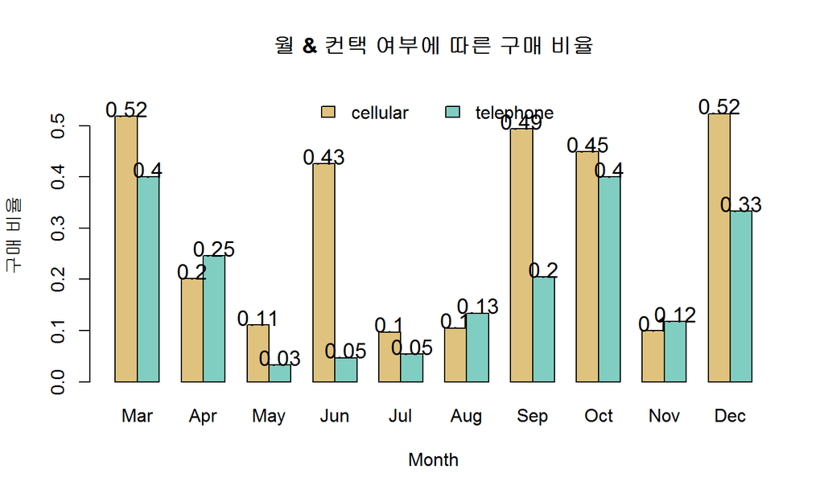

## 구매여부에 따른 duration 분포

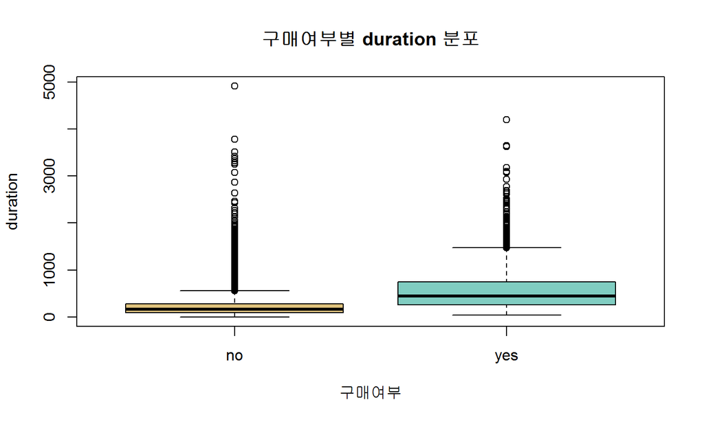

- duration의 분포를 보기 위해 그렸지만, 분포의 형태를 재대로 알 수 없다.
  - 이상치가 많아 분포가 제대로 보이지 않는다.

## 구매여부에 따른 duration 분포

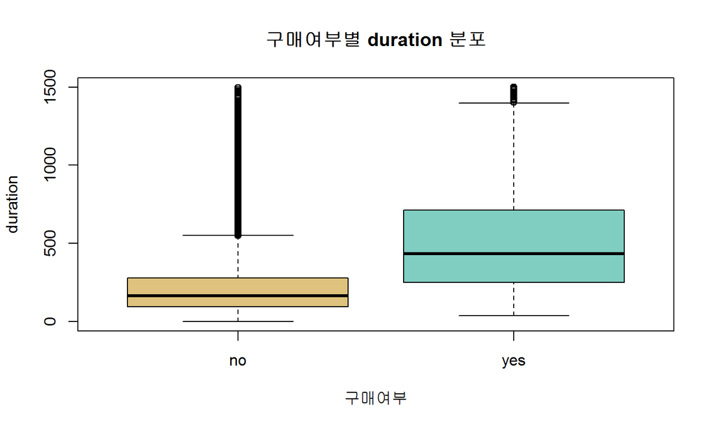

- 전체 duration중 1500 이상을 삭제 후 분포를 보면 구매여부에 따른 분포의 차이가 뚜렷하다.
- 구매 여부가 있는 쪽이 없는쪽에 비해 더 duration의 값이 크게 분포한다.

## 이전 마케팅 결과와 비교

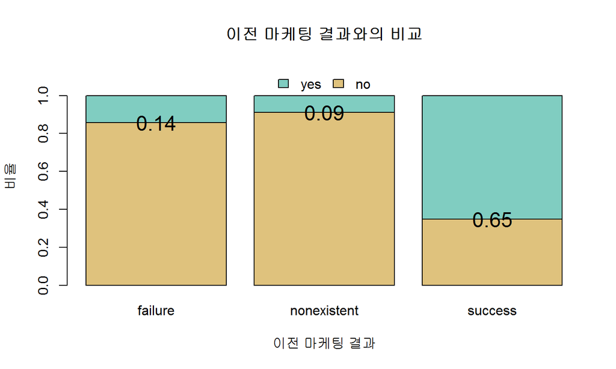

- 이전 마케팅 실패한 고객에게 재추천 할 경우 구매할 확률이 14%가 증가한다. 또한 성공한 고객의 경우 재구매 할 확률이 65%가 된다. 그에 비해 처음 접촉한 고객이 구매할 확률은 9%이다.
- 이는 고객을 찾을때, 마케팅을 한번이라도 접한 고객에게 더 구매할 가능성이 높음을 의미한다.

## 월별 구매여부 비교

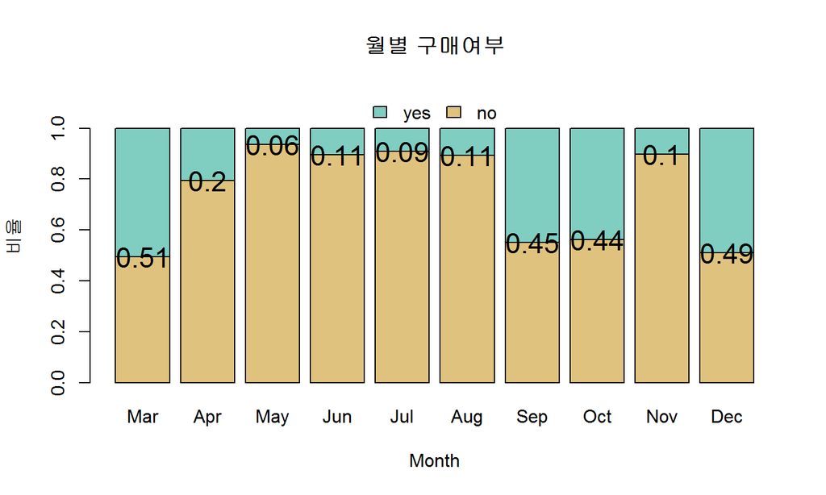

- 3, 9, 10, 12월이 다른 월에 비해 구매 비율이 높다. 왜 그럴까??

## 월별 구매여부 비교

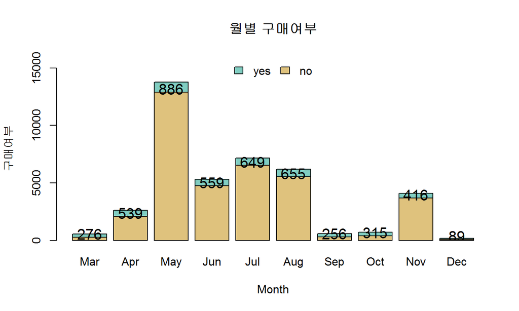

- 3, 9, 10, 12월은 구매수도 적지만 전체저인 컨택이 적다.
- 그에 비해 4, 5, 6, 7, 8, 11월은 컨택을 많이 했음에도 불구하고 성공률이 높아 보이지 않는다.

## 월별 구매여부 비교

- 그래프의 수치는 campaign의 영향을 미친 성공의 수치가 아닌 한달에 얼마나 판매를 했는지에 대한 단순 지표이기 때문이다.
- 3, 9, 10, 12월은 campaign을 하지 않았다고 가정하자.
  - 즉, 기본적으로 구매하는 사람의 수라고 하자. 이 4개월의 평균 판매인원은 234명이다.
- 이 수치를 기준으로 잡고, 성공률을 다음과 같이 정의해보자.

  $$\mbox{성공률} = \frac{\mbox{campaign을 했을때 판매 횟수}}{\mbox{campaingn을 했을때 판매 횟수 - 234}}$$
- 새로 정의한 성공률의 그래프는 다음과 같다.

## 월별 구매 여부 비교

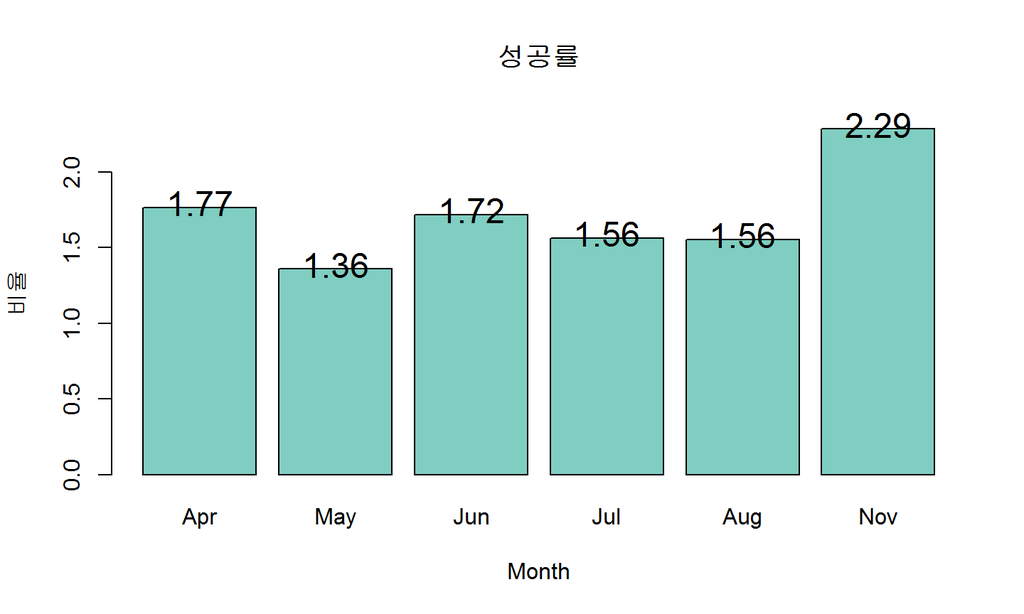

- 각 월별 살펴보면 campaign 했을때 더 성공이 높다고 판단할 수 있게 그려지고 있다.
- 특히 11월달에는 다른 월에 비해 더 높은 수치가 나오고 있다.

## 마지막 컨택이후 지난 일수와 구매여부

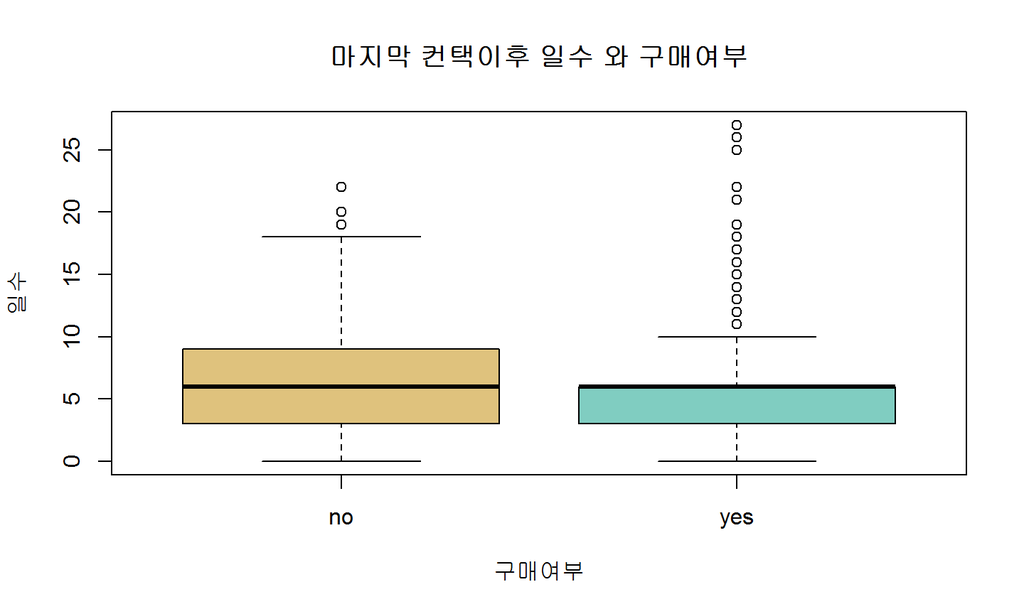

- 구매를 한 사람의 분포를 보면 마지막 컨택이후 일수가 구매 안한 사람들의 분포보다 더 작은 곳에 분포했다고 판단 할 수 있다.

## 종업원수과 구매여부

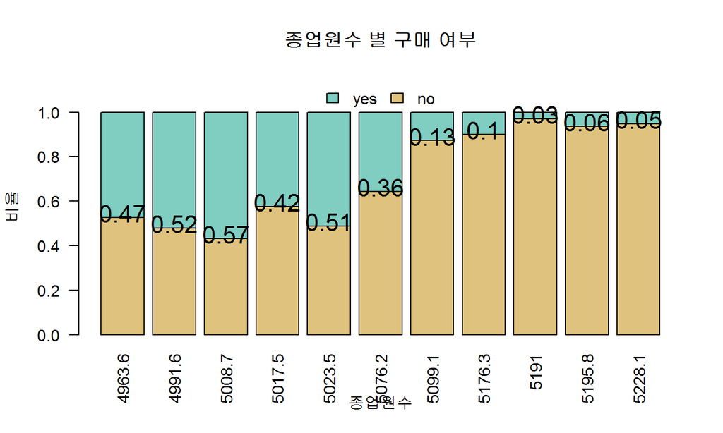

- 종업원수가 증가할수록 구매비율이 더 감소함을 알 수 있다.
- 왜그럴까??

## 월별 종업원수

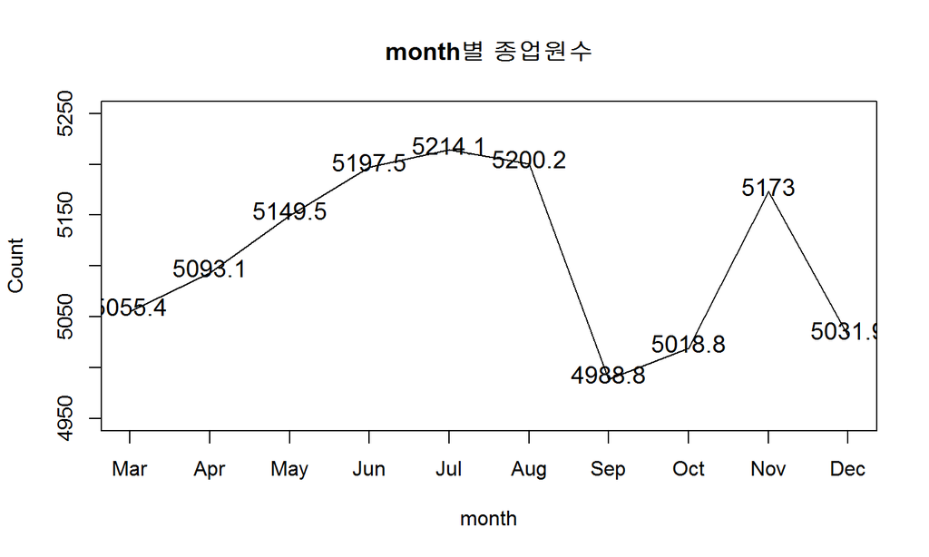

- 월별 종업원수를 보면 6, 7, 8 월에 높고, 9, 10, 12월에 낮음을 알 수 있다.
- 따라서 종업원수가 증가하면, 구매비율도 감소함을 알 수 있다. 왜 이런 현상이 발생할까??

## Code

```r
means = aggregate(nr.employed ~ month, data = bank_dat, mean)

l_plot = plot(means[, 2] , main = "month별 종업원수", type = "l",
              xlab = "month", ylab = "Count", xaxt="n", ylim = c(4950, 5250))
axis(1, at=1:10, labels=means[, 1])
text(x = means[, 1],y =  means[, 2] + 5, labels = round(means[, 2], 1), cex = 1.2)
```

- plot option
  - xaxt : x축 label들 제거
- axis(x, at = ~, labels = ~) : x축에 쓸 text 지정
  - x = 1 : x축을 의미
  - at : 위치 지정
  - labels : x축에 쓸 text지정

## 월별 성공률 및 종업원수

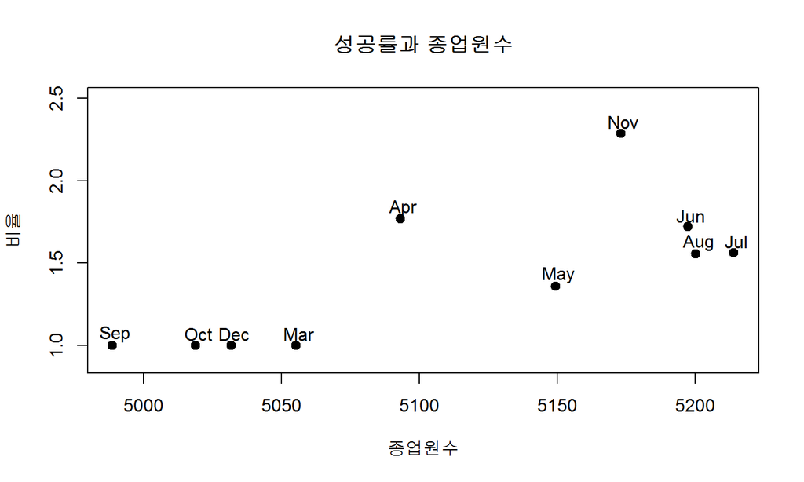

- 앞서 살펴본 성공률로 확인하면, 종업원수가 증가하면 성공률은 증가 한다고 볼수 있다.

## census income data set

## census income data 설명

- Barry Becker from the 1994 Census database 에서 추출했고,
- 데이터 출처 : https://archive.ics.uci.edu/ml/datasets/Census+Income
- 14개 변수와 48842 관측치
- 변수 설명
  - taregt (2개 범주 : "50000>", "50000<=")
  - age
  - workclass (9개 범주 : "Private", "Self-emp-not-inc", "Self-emp-inc", "Federal-gov", "Local-gov", "State-gov", "Without-pay", "Never-worked", "?")
  - fnlwgt : 경제적 특성을 가중계산한 인구합계

## cencus incom data 설명

- 변수 설명
  - education (16개 범주 : "Bachelors", "Some-college", "11th", "HS-grad", "Prof-school", "Assoc-acdm", "Assoc-voc", "9th", "7th-8th", "12th", "Masters", "1st-4th", "10th", "Doctorate", "5th-6th", "Preschool")
  - education-num : education의 숫자형 자료
  - marital-status (7개 범주 : "Married-civ-spouse", "Divorced", "Never-married", "Separated", "Widowed", "Married-spouse-absent", "Married-AF-spouse")
  - occupation (15개 범주 : "Tech-support", "Craft-repair", "Other-service", "Sales", "Exec-managerial", "Prof-specialty", "Handlers-cleaners", "Machine-op-inspct", "Adm-clerical", "Farming-fishing", "Transport-moving", "Priv-house-serv", "Protective-serv", "Armed-Forces", "?")

## cencus incom data 설명

- 변수 설명
  - relationship (6개 범주 : "Wife", "Own-child", "Husband", "Not-in-family", "Other-relative", "Unmarried")
  - race (5개 범주 : "White", "Asian-Pac-Islander", "Amer-Indian-Eskimo", "Other", "Black")
  - sex (2개 범주 : "Female", "Male")
  - capital-gain
  - capital-loss
  - hours-per-week
  - native-country (42개 범주 : "United-States", "Cambodia", "England", "Puerto-Rico", "Canada", "Germany", "Outlying-US(Guam-USVI-etc)", "India", "Japan", "Greece", "South", "China", "Cuba", "Iran", "Honduras", "Philippines", "Italy", …, "Peru", "Hong", "Holand-Netherlands", "?")

## 데이터 구조

```r
str(census_dat)
```

```
## 'data.frame':    32561 obs. of  15 variables:
##  $ age           : num  39 50 38 53 28 37 49 52 31 42 ...
##  $ workclass     : chr  "State-gov" "Self-emp-not-inc" "Private" "Private" ...
##  $ fnlwgt        : num  77516 83311 215646 234721 338409 ...
##  $ education     : Factor w/ 16 levels "Preschool","1st-4th",..: 13 13 9 7 13 14 5 9 14 13 ...
##  $ education-num : num  13 13 9 7 13 14 5 9 14 13 ...
##  $ marital-status: chr  "Never-married" "Married-civ-spouse" "Divorced" "Married-civ-spouse" ...
##  $ occupation    : chr  "Adm-clerical" "Exec-managerial" "Handlers-cleaners" "Handlers-cleaners" ...
##  $ relationship  : chr  "Not-in-family" "Husband" "Not-in-family" "Husband" ...
##  $ race          : chr  "White" "White" "White" "Black" ...
##  $ sex           : chr  "Male" "Male" "Male" "Male" ...
##  $ capital-gain  : num  2174 0 0 0 0 ...
##  $ capital-loss  : num  0 0 0 0 0 0 0 0 0 0 ...
##  $ hours-per-week: num  40 13 40 40 40 40 16 45 50 40 ...
##  $ native-country: chr  "United-States" "United-States" "United-States" "United-States" ...
##  $ target        : chr  "<=50K" "<=50K" "<=50K" "<=50K" ...
```

## 나이와 수입 관계

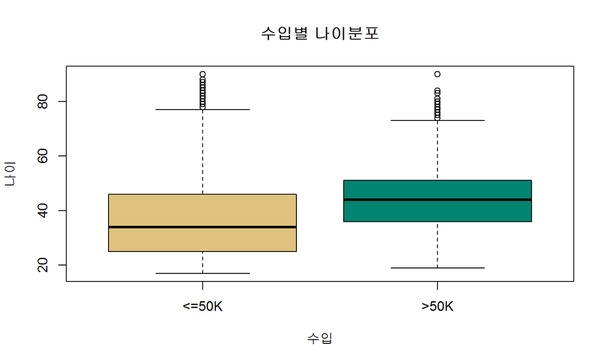

- 수입에 따른 나이의 분포를 살펴보면, 예상할 수 있듯이 수입이 높은 그룹이 나이가 많은 분포로 나타나고 있다.

## 교육과 수입 관계

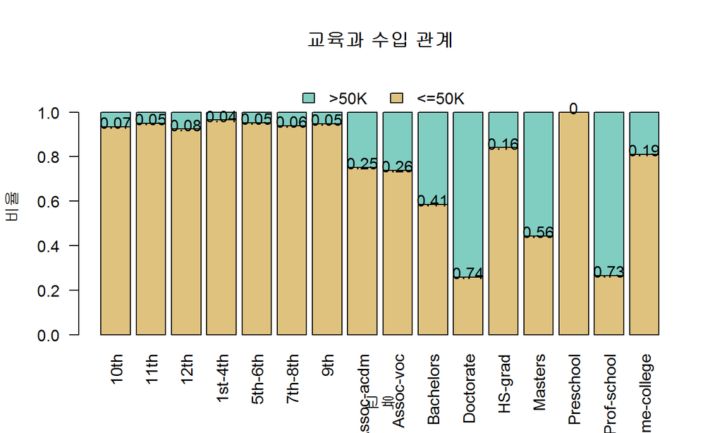

- 교육수준이 높으면 수입이 높다는 관계가 보이긴 하지만 잘 보이지 않는다.

## 교육과 수입 관계

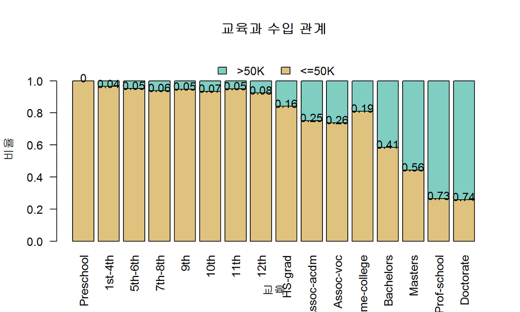

- 교육수준에 대해 정렬후 보면, 교육수준이 증가할수록 수입증가의 비율이 증가 한다는 뚜렷한 현상을 관측할 수 있다.

## capital-gain

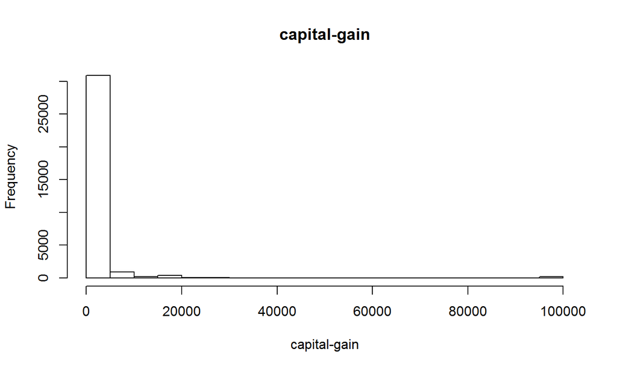

- 그래프의 분포가 다른 gain값에서는 빈도가 나타나지 않는것처럼 보인다.

## capital-gain

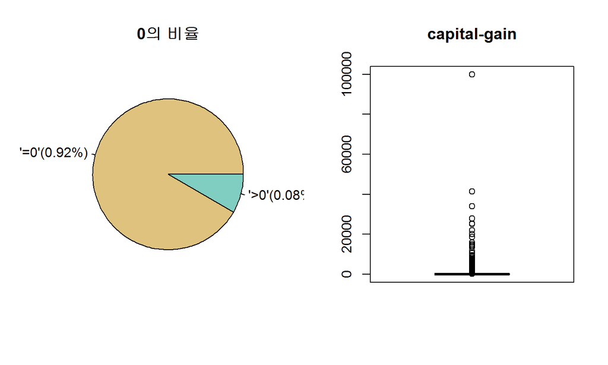

- pie chart에서 나타나듯이 capital-gain 변수에는 0의 비율이 92%나 되고, boxplot에서는 100000의 값이 나타난다. 때문에 실제 다른 capital-gain에서 값이 존재하더라도 없는 상황처럼 보여진다.

## Code

```r
par(mfrow = c(1, 2))
pie(prob, labels = ratio_name, col = c(brewer.pal(5, 'BrBG')[c(2, 4)]), main = "0의 비율")
boxplot(`capital-gain`, main = "capital-gain")
par(mfrow = c(1, 1))
```

- par(mfrow = c(1, 2))
  - 그래프 그리는 공간을 분할해줌

## capital-gain

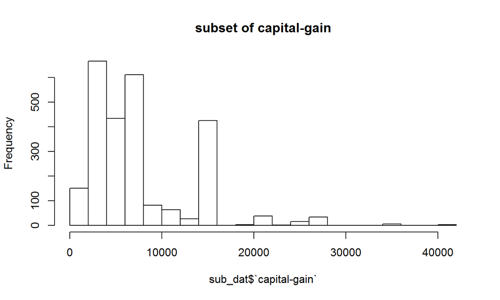

- 0과 99999값을 제거후 그린 histogram이다.

## capital-loss

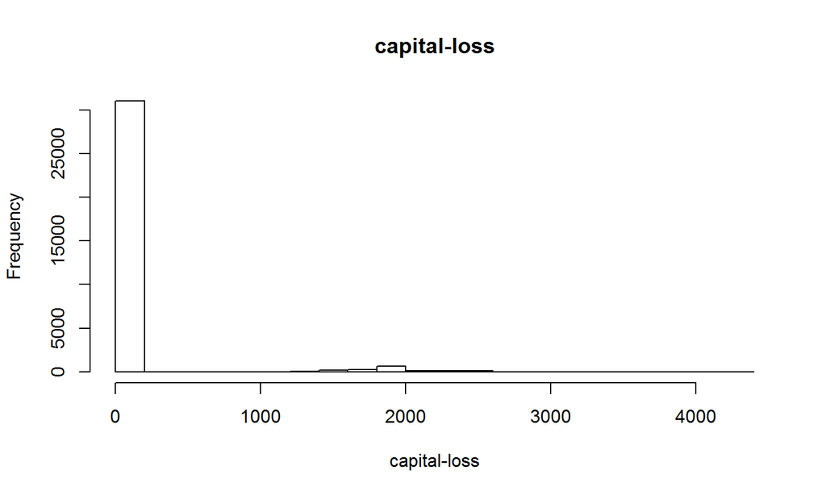

- loss의 그래프 역시 다른 loss값에서는 빈도가 나타나지 않는것처럼 보인다.
  - gain에서 와 마찬가지로 0의 빈도가 상당히 높다.

## capital-loss

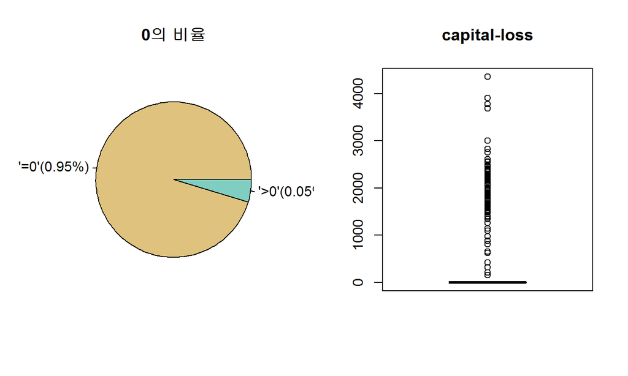

- boxplot을 보면 gain처럼 극단적인 값은 존재하지 않지만, pie chart에서 capital-loss 변수에는 0의 비율이 95%를 차지하고 있다. 때문에 실제 다른 capital-loss에서 값이 존재하더라도 없는 상황처럼 보여진다.

## capital-loss

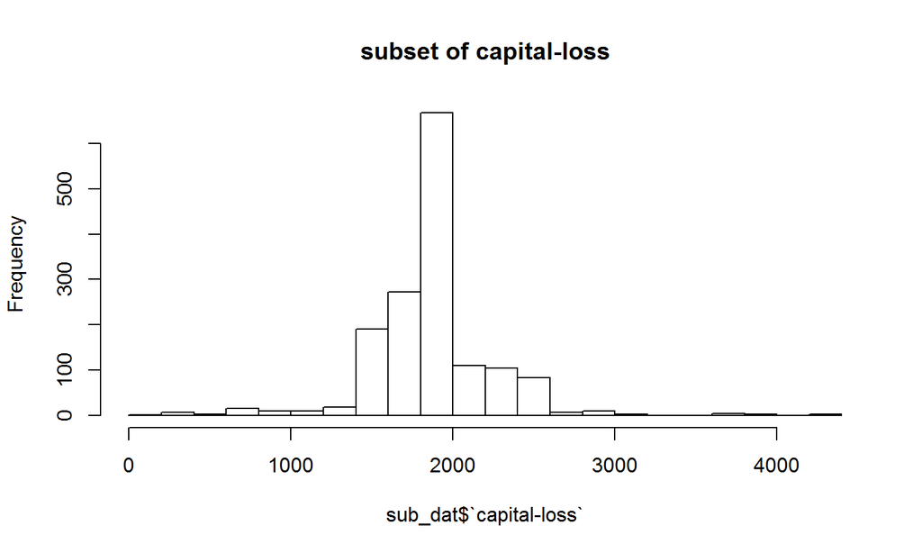

- 0과 99999값을 제거후 그린 histogram이다.

## capital-gain과 hours-per-week 관계

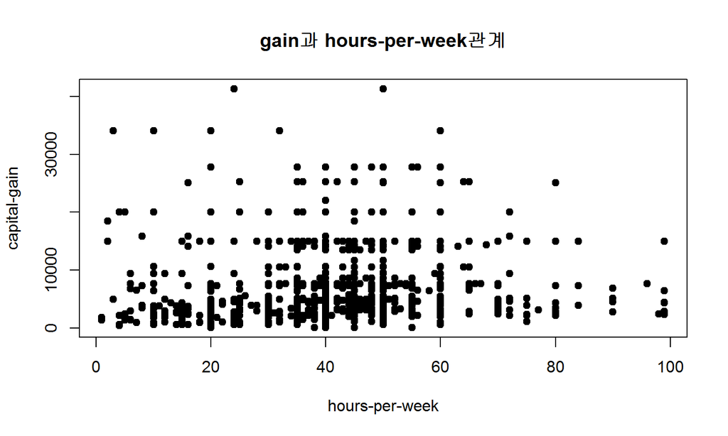

- 그래프만 보게 되면 사용된 관측치의 수가 상당히 적어 보인다. 왜그럴까??

## capital-gain과 hours-per-week 관계

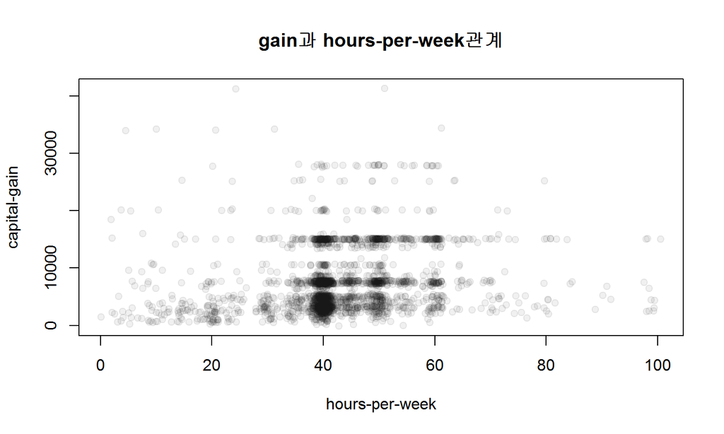

- 겹침현상을 제거 시키기 위해 점마다 위치를 살짝 바꿔주고, 색상에 투명도를 주어 찍으면 다음과 같이 많이 모여 찍히는 부분은 더 색상이 잘 보이는 것을 알 수 있다.

## Code

```r
plot(sub_dat$`hours-per-week` + rnorm(n), sub_dat$`capital-gain` + rnorm(n)*100, main = "gain과 hours-per-week관계" , ylab = "capital-gain", xlab = "hours-per-week",  pch = 19, col = "#11111110")
```

- rnorm(n) : 정규분포에서 난수 생성하는 함수
  - n개의 난수를 표준정규분포(평균 = 0, 분산 = 1 인 정규분포)에서 생성함

## capital-gain과 education 관계

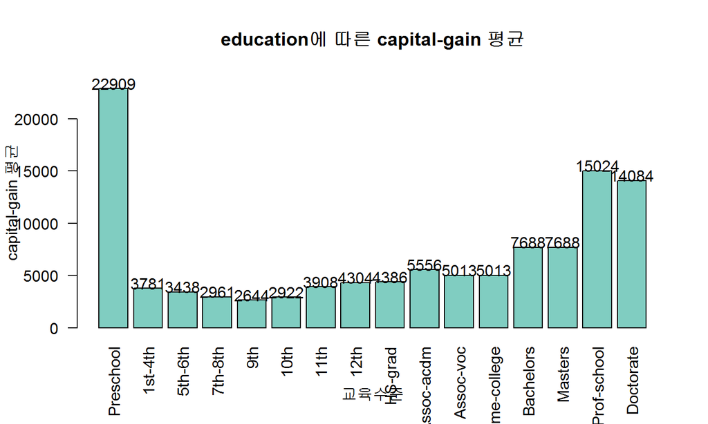

- capital-gain에서 0과 99999값을 제외한 그래프이다.
- 예상과는 다르게 "Preschool"이 가장 높은 이익을 낸다는 것을 알 수 있다. 왜그럴까??

## capital-gain과 education 관계

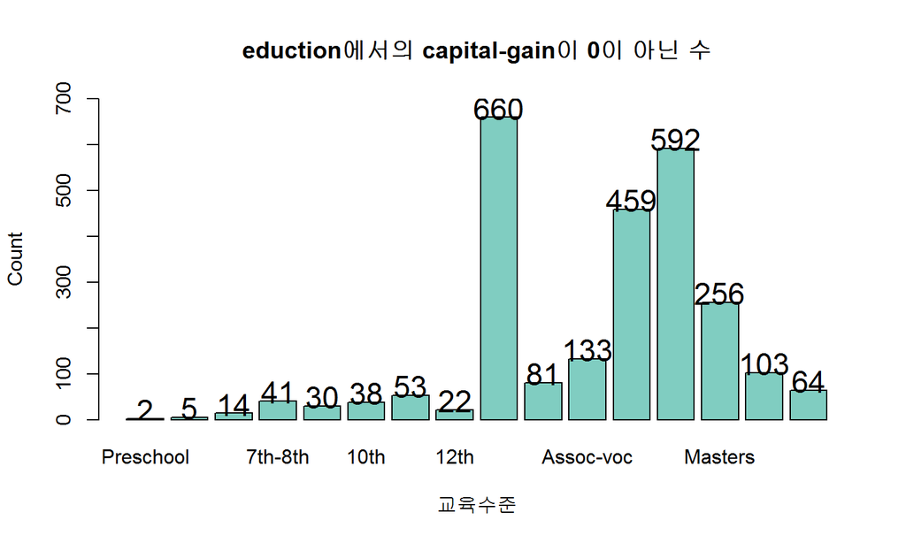

- 교육수준의 범주별 0이 아닌 사람의 수를 보면 Preschool은 2명만 capital-gain이 발생함을 알 수 있다.

## capital-gain과 education 관계

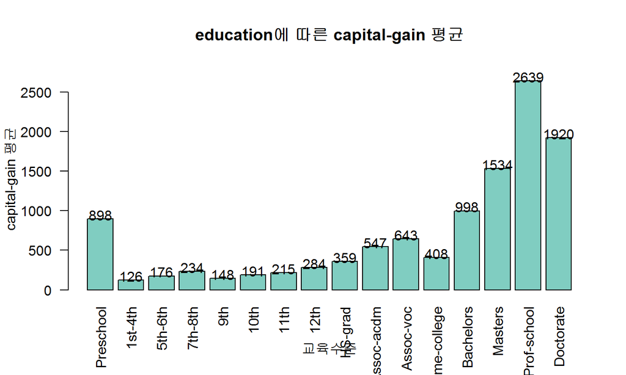

- 0을 포함한 그래프를 다시 살펴보면 전체적으로 값이 감소함을 알 수 있지만, 특히 `Preschool`의 경우 감소폭이 엄청나다는 것을 알 수 있다.
- 앞서 histogram을 그릴때는 0을 제외 했지만, 분석 할 때 0을 제외해서는 안된다.